# Risk Factor Analysis

## Outcome Variable

**Outcome Variable:** ever_stunted

## Predictor Variables

**Intervention Variable:** fage

**Adjustment Set:**

unadjusted

## Stratifying Variables

The analysis was stratified on these variable(s):

- agecat
- studyid
- country

## Data Summary

| agecat | studyid | country | fage | ever_stunted | n_cell | n |
| --- | --- | --- | --- | --- | --- | --- |
| 0-6 months | ki0047075b-MAL-ED | BANGLADESH | >=35 | 0 | 86 | 151 |
| 0-6 months | ki0047075b-MAL-ED | BANGLADESH | >=35 | 1 | 16 | 151 |
| 0-6 months | ki0047075b-MAL-ED | BANGLADESH | [25-30) | 0 | 11 | 151 |
| 0-6 months | ki0047075b-MAL-ED | BANGLADESH | [25-30) | 1 | 3 | 151 |
| 0-6 months | ki0047075b-MAL-ED | BANGLADESH | [30-35) | 0 | 33 | 151 |
| 0-6 months | ki0047075b-MAL-ED | BANGLADESH | [30-35) | 1 | 2 | 151 |
| 0-6 months | ki0047075b-MAL-ED | BRAZIL | >=35 | 0 | 36 | 79 |
| 0-6 months | ki0047075b-MAL-ED | BRAZIL | >=35 | 1 | 4 | 79 |
| 0-6 months | ki0047075b-MAL-ED | BRAZIL | <25 | 0 | 3 | 79 |
| 0-6 months | ki0047075b-MAL-ED | BRAZIL | <25 | 1 | 0 | 79 |
| 0-6 months | ki0047075b-MAL-ED | BRAZIL | [25-30) | 0 | 8 | 79 |
| 0-6 months | ki0047075b-MAL-ED | BRAZIL | [25-30) | 1 | 0 | 79 |
| 0-6 months | ki0047075b-MAL-ED | BRAZIL | [30-35) | 0 | 23 | 79 |
| 0-6 months | ki0047075b-MAL-ED | BRAZIL | [30-35) | 1 | 5 | 79 |
| 0-6 months | ki0047075b-MAL-ED | INDIA | >=35 | 0 | 63 | 161 |
| 0-6 months | ki0047075b-MAL-ED | INDIA | >=35 | 1 | 8 | 161 |
| 0-6 months | ki0047075b-MAL-ED | INDIA | <25 | 0 | 3 | 161 |
| 0-6 months | ki0047075b-MAL-ED | INDIA | <25 | 1 | 0 | 161 |
| 0-6 months | ki0047075b-MAL-ED | INDIA | [25-30) | 0 | 23 | 161 |
| 0-6 months | ki0047075b-MAL-ED | INDIA | [25-30) | 1 | 4 | 161 |
| 0-6 months | ki0047075b-MAL-ED | INDIA | [30-35) | 0 | 47 | 161 |
| 0-6 months | ki0047075b-MAL-ED | INDIA | [30-35) | 1 | 13 | 161 |
| 0-6 months | ki0047075b-MAL-ED | NEPAL | >=35 | 0 | 35 | 79 |
| 0-6 months | ki0047075b-MAL-ED | NEPAL | >=35 | 1 | 3 | 79 |
| 0-6 months | ki0047075b-MAL-ED | NEPAL | [25-30) | 0 | 9 | 79 |
| 0-6 months | ki0047075b-MAL-ED | NEPAL | [25-30) | 1 | 1 | 79 |
| 0-6 months | ki0047075b-MAL-ED | NEPAL | [30-35) | 0 | 27 | 79 |
| 0-6 months | ki0047075b-MAL-ED | NEPAL | [30-35) | 1 | 4 | 79 |
| 0-6 months | ki0047075b-MAL-ED | PERU | >=35 | 0 | 42 | 85 |
| 0-6 months | ki0047075b-MAL-ED | PERU | >=35 | 1 | 3 | 85 |

[output cut: 268 more lines]

The following strata were considered:

- agecat: 0-24 months, studyid: ki0047075b-MAL-ED, country: BANGLADESH
- agecat: 0-24 months, studyid: ki0047075b-MAL-ED, country: BRAZIL
- agecat: 0-24 months, studyid: ki0047075b-MAL-ED, country: INDIA
- agecat: 0-24 months, studyid: ki0047075b-MAL-ED, country: NEPAL
- agecat: 0-24 months, studyid: ki0047075b-MAL-ED, country: PERU
- agecat: 0-24 months, studyid: ki0047075b-MAL-ED, country: SOUTH AFRICA
- agecat: 0-24 months, studyid: ki0047075b-MAL-ED, country: TANZANIA, UNITED REPUBLIC OF
- agecat: 0-24 months, studyid: ki1000304b-SAS-CompFeed, country: INDIA
- agecat: 0-24 months, studyid: ki1000304b-SAS-FoodSuppl, country: INDIA
- agecat: 0-24 months, studyid: ki1119695-PROBIT, country: BELARUS
- agecat: 0-24 months, studyid: ki1135781-COHORTS, country: GUATEMALA
- agecat: 0-24 months, studyid: ki1135781-COHORTS, country: PHILIPPINES
- agecat: 0-24 months, studyid: ki1148112-LCNI-5, country: MALAWI
- agecat: 0-6 months, studyid: ki0047075b-MAL-ED, country: BANGLADESH
- agecat: 0-6 months, studyid: ki0047075b-MAL-ED, country: BRAZIL
- agecat: 0-6 months, studyid: ki0047075b-MAL-ED, country: INDIA
- agecat: 0-6 months, studyid: ki0047075b-MAL-ED, country: NEPAL
- agecat: 0-6 months, studyid: ki0047075b-MAL-ED, country: PERU
- agecat: 0-6 months, studyid: ki0047075b-MAL-ED, country: SOUTH AFRICA
- agecat: 0-6 months, studyid: ki0047075b-MAL-ED, country: TANZANIA, UNITED REPUBLIC OF
- agecat: 0-6 months, studyid: ki1000304b-SAS-CompFeed, country: INDIA
- agecat: 0-6 months, studyid: ki1000304b-SAS-FoodSuppl, country: INDIA
- agecat: 0-6 months, studyid: ki1119695-PROBIT, country: BELARUS
- agecat: 0-6 months, studyid: ki1135781-COHORTS, country: GUATEMALA
- agecat: 0-6 months, studyid: ki1135781-COHORTS, country: PHILIPPINES
- agecat: 0-6 months, studyid: ki1148112-LCNI-5, country: MALAWI
- agecat: 6-24 months, studyid: ki0047075b-MAL-ED, country: BANGLADESH
- agecat: 6-24 months, studyid: ki0047075b-MAL-ED, country: BRAZIL
- agecat: 6-24 months, studyid: ki0047075b-MAL-ED, country: INDIA
- agecat: 6-24 months, studyid: ki0047075b-MAL-ED, country: NEPAL
- agecat: 6-24 months, studyid: ki0047075b-MAL-ED, country: PERU
- agecat: 6-24 months, studyid: ki0047075b-MAL-ED, country: SOUTH AFRICA
- agecat: 6-24 months, studyid: ki0047075b-MAL-ED, country: TANZANIA, UNITED REPUBLIC OF
- agecat: 6-24 months, studyid: ki1000304b-SAS-CompFeed, country: INDIA
- agecat: 6-24 months, studyid: ki1000304b-SAS-FoodSuppl, country: INDIA
- agecat: 6-24 months, studyid: ki1119695-PROBIT, country: BELARUS
- agecat: 6-24 months, studyid: ki1135781-COHORTS, country: GUATEMALA
- agecat: 6-24 months, studyid: ki1135781-COHORTS, country: PHILIPPINES
- agecat: 6-24 months, studyid: ki1148112-LCNI-5, country: MALAWI

### Dropped Strata

Some strata were dropped due to rare outcomes:

- agecat: 0-6 months, studyid: ki0047075b-MAL-ED, country: BANGLADESH
- agecat: 0-6 months, studyid: ki0047075b-MAL-ED, country: BRAZIL
- agecat: 0-6 months, studyid: ki0047075b-MAL-ED, country: INDIA
- agecat: 0-6 months, studyid: ki0047075b-MAL-ED, country: NEPAL
- agecat: 0-6 months, studyid: ki0047075b-MAL-ED, country: PERU
- agecat: 0-6 months, studyid: ki0047075b-MAL-ED, country: SOUTH AFRICA
- agecat: 0-6 months, studyid: ki0047075b-MAL-ED, country: TANZANIA, UNITED REPUBLIC OF
- agecat: 0-6 months, studyid: ki1148112-LCNI-5, country: MALAWI
- agecat: 6-24 months, studyid: ki0047075b-MAL-ED, country: BANGLADESH
- agecat: 6-24 months, studyid: ki0047075b-MAL-ED, country: BRAZIL
- agecat: 6-24 months, studyid: ki0047075b-MAL-ED, country: INDIA
- agecat: 6-24 months, studyid: ki0047075b-MAL-ED, country: NEPAL
- agecat: 6-24 months, studyid: ki0047075b-MAL-ED, country: PERU
- agecat: 6-24 months, studyid: ki0047075b-MAL-ED, country: SOUTH AFRICA
- agecat: 6-24 months, studyid: ki0047075b-MAL-ED, country: TANZANIA, UNITED REPUBLIC OF
- agecat: 6-24 months, studyid: ki1148112-LCNI-5, country: MALAWI
- agecat: 0-24 months, studyid: ki0047075b-MAL-ED, country: BRAZIL
- agecat: 0-24 months, studyid: ki0047075b-MAL-ED, country: INDIA
- agecat: 0-24 months, studyid: ki0047075b-MAL-ED, country: NEPAL
- agecat: 0-24 months, studyid: ki0047075b-MAL-ED, country: PERU
- agecat: 0-24 months, studyid: ki0047075b-MAL-ED, country: SOUTH AFRICA
- agecat: 0-24 months, studyid: ki0047075b-MAL-ED, country: TANZANIA, UNITED REPUBLIC OF

## Methods Detail

We’re interested in the causal parameters $E[Y_a]$ for all values of $a \in \mathcal{A}$. These parameters represent the mean outcome if, possibly contrary to fact, we intervened to set all units to have $A=a$. Under the randomization and positivity assumptions, these are identified by the statistical parameters $\psi_a=E_W[E_{Y|A,W}(Y|A=a,W)]$. In addition, we’re interested in the mean of $Y$, $E[Y]$ under no intervention (the observed mean). We will estimate these parameters by using SuperLearner to fit the relevant likelihood factors – $E_{Y|A,W}(Y|A=a,W)$ and $p(A=a|W)$, and then updating our likelihood fit using a joint TMLE.

For unadjusted analyses ($W=\{\}$), initial likelihoods were estimated using Lrnr_glm to estimate the simple $E(Y|A)$ and Lrnr_mean to estimate $p(A)$. For adjusted analyses, a small library containing Lrnr_glmnet, Lrnr_xgboost, and Lrnr_mean was used.

Having estimated these parameters, we will then use the delta method to estimate relative risks and attributable risks relative to a prespecified baseline level of $A$.

# Results Detail

## Results Plots

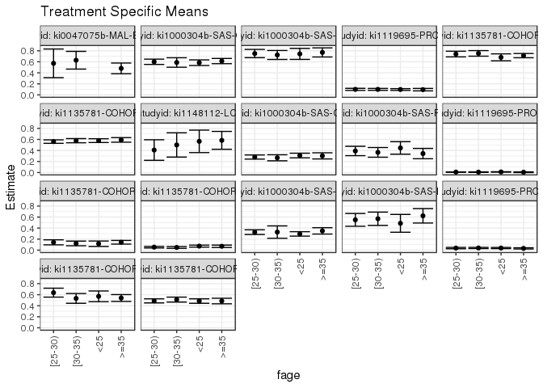

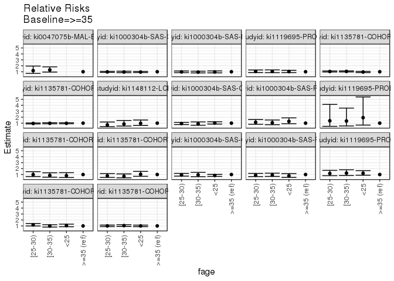

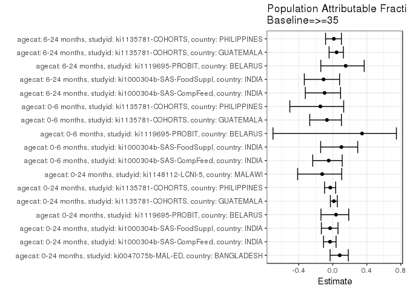

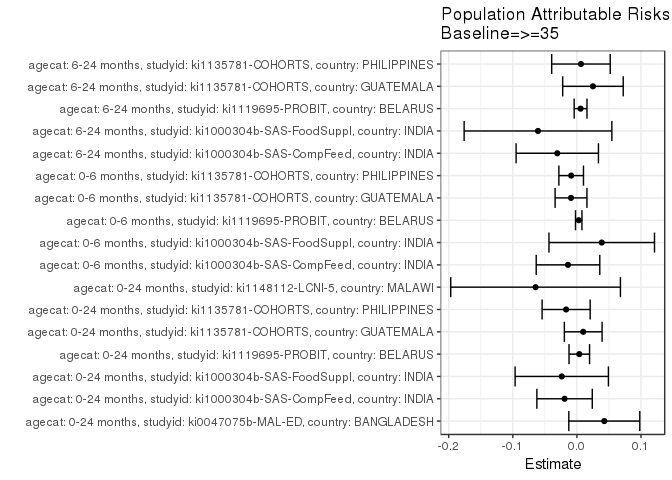

## Results Table

### Parameter: TSM

| agecat | studyid | country | intervention_level | baseline_level | estimate | ci_lower | ci_upper |
| --- | --- | --- | --- | --- | --- | --- | --- |
| 0-24 months | ki0047075b-MAL-ED | BANGLADESH | >=35 | NA | 0.4803922 | 0.3831115 | 0.5776728 |
| 0-24 months | ki0047075b-MAL-ED | BANGLADESH | [25-30) | NA | 0.5714286 | 0.3113411 | 0.8315161 |
| 0-24 months | ki0047075b-MAL-ED | BANGLADESH | [30-35) | NA | 0.6285714 | 0.4679617 | 0.7891812 |
| 0-24 months | ki1000304b-SAS-CompFeed | INDIA | >=35 | NA | 0.6133333 | 0.5661574 | 0.6605092 |
| 0-24 months | ki1000304b-SAS-CompFeed | INDIA | <25 | NA | 0.5835189 | 0.5329235 | 0.6341144 |
| 0-24 months | ki1000304b-SAS-CompFeed | INDIA | [25-30) | NA | 0.6003185 | 0.5525846 | 0.6480523 |
| 0-24 months | ki1000304b-SAS-CompFeed | INDIA | [30-35) | NA | 0.5874587 | 0.5016944 | 0.6732231 |
| 0-24 months | ki1000304b-SAS-FoodSuppl | INDIA | >=35 | NA | 0.7700000 | 0.6874195 | 0.8525805 |
| 0-24 months | ki1000304b-SAS-FoodSuppl | INDIA | <25 | NA | 0.7432432 | 0.6435929 | 0.8428936 |
| 0-24 months | ki1000304b-SAS-FoodSuppl | INDIA | [25-30) | NA | 0.7500000 | 0.6748959 | 0.8251041 |
| 0-24 months | ki1000304b-SAS-FoodSuppl | INDIA | [30-35) | NA | 0.7241379 | 0.6427058 | 0.8055701 |
| 0-24 months | ki1119695-PROBIT | BELARUS | >=35 | NA | 0.0949755 | 0.0728718 | 0.1170792 |
| 0-24 months | ki1119695-PROBIT | BELARUS | <25 | NA | 0.0975921 | 0.0812986 | 0.1138856 |
| 0-24 months | ki1119695-PROBIT | BELARUS | [25-30) | NA | 0.1002297 | 0.0816110 | 0.1188483 |
| 0-24 months | ki1119695-PROBIT | BELARUS | [30-35) | NA | 0.0997718 | 0.0821663 | 0.1173772 |
| 0-24 months | ki1135781-COHORTS | GUATEMALA | >=35 | NA | 0.7118644 | 0.6733286 | 0.7504003 |
| 0-24 months | ki1135781-COHORTS | GUATEMALA | <25 | NA | 0.6809524 | 0.6178869 | 0.7440178 |
| 0-24 months | ki1135781-COHORTS | GUATEMALA | [25-30) | NA | 0.7402135 | 0.6889216 | 0.7915054 |
| 0-24 months | ki1135781-COHORTS | GUATEMALA | [30-35) | NA | 0.7526882 | 0.7020424 | 0.8033339 |
| 0-24 months | ki1135781-COHORTS | PHILIPPINES | >=35 | NA | 0.5914972 | 0.5500689 | 0.6329255 |
| 0-24 months | ki1135781-COHORTS | PHILIPPINES | <25 | NA | 0.5781638 | 0.5440640 | 0.6122635 |
| 0-24 months | ki1135781-COHORTS | PHILIPPINES | [25-30) | NA | 0.5607966 | 0.5292986 | 0.5922946 |
| 0-24 months | ki1135781-COHORTS | PHILIPPINES | [30-35) | NA | 0.5769231 | 0.5389362 | 0.6149100 |
| 0-24 months | ki1148112-LCNI-5 | MALAWI | >=35 | NA | 0.5833333 | 0.4215224 | 0.7451443 |
| 0-24 months | ki1148112-LCNI-5 | MALAWI | <25 | NA | 0.5652174 | 0.3616603 | 0.7687745 |
| 0-24 months | ki1148112-LCNI-5 | MALAWI | [25-30) | NA | 0.4074074 | 0.2211914 | 0.5936234 |
| 0-24 months | ki1148112-LCNI-5 | MALAWI | [30-35) | NA | 0.5000000 | 0.2798284 | 0.7201716 |
| 0-6 months | ki1000304b-SAS-CompFeed | INDIA | >=35 | NA | 0.3020134 | 0.2464097 | 0.3576172 |
| 0-6 months | ki1000304b-SAS-CompFeed | INDIA | <25 | NA | 0.3080357 | 0.2658109 | 0.3502605 |
| 0-6 months | ki1000304b-SAS-CompFeed | INDIA | [25-30) | NA | 0.2807018 | 0.2431524 | 0.3182511 |
| 0-6 months | ki1000304b-SAS-CompFeed | INDIA | [30-35) | NA | 0.2673267 | 0.2123019 | 0.3223515 |
| 0-6 months | ki1000304b-SAS-FoodSuppl | INDIA | >=35 | NA | 0.3434343 | 0.2497830 | 0.4370857 |
| 0-6 months | ki1000304b-SAS-FoodSuppl | INDIA | <25 | NA | 0.4459459 | 0.3325567 | 0.5593352 |
| 0-6 months | ki1000304b-SAS-FoodSuppl | INDIA | [25-30) | NA | 0.3906250 | 0.3060021 | 0.4752479 |
| 0-6 months | ki1000304b-SAS-FoodSuppl | INDIA | [30-35) | NA | 0.3652174 | 0.2771105 | 0.4533243 |
| 0-6 months | ki1119695-PROBIT | BELARUS | >=35 | NA | 0.0055215 | -0.0007239 | 0.0117669 |
| 0-6 months | ki1119695-PROBIT | BELARUS | <25 | NA | 0.0105820 | 0.0067304 | 0.0144337 |
| 0-6 months | ki1119695-PROBIT | BELARUS | [25-30) | NA | 0.0077112 | 0.0046813 | 0.0107412 |
| 0-6 months | ki1119695-PROBIT | BELARUS | [30-35) | NA | 0.0074992 | 0.0034505 | 0.0115478 |
| 0-6 months | ki1135781-COHORTS | GUATEMALA | >=35 | NA | 0.1431871 | 0.1101801 | 0.1761940 |
| 0-6 months | ki1135781-COHORTS | GUATEMALA | <25 | NA | 0.1165644 | 0.0672775 | 0.1658513 |
| 0-6 months | ki1135781-COHORTS | GUATEMALA | [25-30) | NA | 0.1415929 | 0.0961184 | 0.1870674 |
| 0-6 months | ki1135781-COHORTS | GUATEMALA | [30-35) | NA | 0.1217391 | 0.0794608 | 0.1640174 |
| 0-6 months | ki1135781-COHORTS | PHILIPPINES | >=35 | NA | 0.0702403 | 0.0487025 | 0.0917781 |
| 0-6 months | ki1135781-COHORTS | PHILIPPINES | <25 | NA | 0.0732010 | 0.0552162 | 0.0911858 |
| 0-6 months | ki1135781-COHORTS | PHILIPPINES | [25-30) | NA | 0.0545073 | 0.0400993 | 0.0689153 |
| 0-6 months | ki1135781-COHORTS | PHILIPPINES | [30-35) | NA | 0.0492308 | 0.0325958 | 0.0658657 |
| 6-24 months | ki1000304b-SAS-CompFeed | INDIA | >=35 | NA | 0.3493976 | 0.2917145 | 0.4070807 |
| 6-24 months | ki1000304b-SAS-CompFeed | INDIA | <25 | NA | 0.2943144 | 0.2542582 | 0.3343706 |
| 6-24 months | ki1000304b-SAS-CompFeed | INDIA | [25-30) | NA | 0.3267327 | 0.2844360 | 0.3690294 |
| 6-24 months | ki1000304b-SAS-CompFeed | INDIA | [30-35) | NA | 0.3276836 | 0.2155404 | 0.4398268 |
| 6-24 months | ki1000304b-SAS-FoodSuppl | INDIA | >=35 | NA | 0.6226415 | 0.4918531 | 0.7534299 |
| 6-24 months | ki1000304b-SAS-FoodSuppl | INDIA | <25 | NA | 0.4864865 | 0.3250798 | 0.6478932 |
| 6-24 months | ki1000304b-SAS-FoodSuppl | INDIA | [25-30) | NA | 0.5492958 | 0.4333030 | 0.6652885 |
| 6-24 months | ki1000304b-SAS-FoodSuppl | INDIA | [30-35) | NA | 0.5692308 | 0.4485826 | 0.6898790 |
| 6-24 months | ki1119695-PROBIT | BELARUS | >=35 | NA | 0.0321564 | 0.0212824 | 0.0430304 |
| 6-24 months | ki1119695-PROBIT | BELARUS | <25 | NA | 0.0388111 | 0.0282741 | 0.0493480 |
| 6-24 months | ki1119695-PROBIT | BELARUS | [25-30) | NA | 0.0377615 | 0.0251043 | 0.0504188 |
| 6-24 months | ki1119695-PROBIT | BELARUS | [30-35) | NA | 0.0397039 | 0.0290827 | 0.0503251 |
| 6-24 months | ki1135781-COHORTS | GUATEMALA | >=35 | NA | 0.5400000 | 0.4781682 | 0.6018318 |
| 6-24 months | ki1135781-COHORTS | GUATEMALA | <25 | NA | 0.5700000 | 0.4728869 | 0.6671131 |
| 6-24 months | ki1135781-COHORTS | GUATEMALA | [25-30) | NA | 0.6370370 | 0.5558563 | 0.7182177 |
| 6-24 months | ki1135781-COHORTS | GUATEMALA | [30-35) | NA | 0.5327869 | 0.4441814 | 0.6213923 |
| 6-24 months | ki1135781-COHORTS | PHILIPPINES | >=35 | NA | 0.4854881 | 0.4351593 | 0.5358169 |
| 6-24 months | ki1135781-COHORTS | PHILIPPINES | <25 | NA | 0.4846416 | 0.4441686 | 0.5251146 |
| 6-24 months | ki1135781-COHORTS | PHILIPPINES | [25-30) | NA | 0.4879433 | 0.4510371 | 0.5248494 |
| 6-24 months | ki1135781-COHORTS | PHILIPPINES | [30-35) | NA | 0.5114823 | 0.4667071 | 0.5562574 |

### Parameter: E(Y)

| agecat | studyid | country | intervention_level | baseline_level | estimate | ci_lower | ci_upper |
| --- | --- | --- | --- | --- | --- | --- | --- |
| 0-24 months | ki0047075b-MAL-ED | BANGLADESH | NA | NA | 0.5231788 | 0.4432496 | 0.6031080 |
| 0-24 months | ki1000304b-SAS-CompFeed | INDIA | NA | NA | 0.5941176 | 0.5531511 | 0.6350842 |
| 0-24 months | ki1000304b-SAS-FoodSuppl | INDIA | NA | NA | 0.7464115 | 0.7046540 | 0.7881689 |
| 0-24 months | ki1119695-PROBIT | BELARUS | NA | NA | 0.0987283 | 0.0829150 | 0.1145416 |
| 0-24 months | ki1135781-COHORTS | GUATEMALA | NA | NA | 0.7217525 | 0.6973920 | 0.7461130 |
| 0-24 months | ki1135781-COHORTS | PHILIPPINES | NA | NA | 0.5747204 | 0.5568801 | 0.5925608 |
| 0-24 months | ki1148112-LCNI-5 | MALAWI | NA | NA | 0.5188679 | 0.4232996 | 0.6144363 |
| 0-6 months | ki1000304b-SAS-CompFeed | INDIA | NA | NA | 0.2881467 | 0.2614090 | 0.3148844 |
| 0-6 months | ki1000304b-SAS-FoodSuppl | INDIA | NA | NA | 0.3822115 | 0.3354600 | 0.4289631 |
| 0-6 months | ki1119695-PROBIT | BELARUS | NA | NA | 0.0084189 | 0.0052961 | 0.0115416 |
| 0-6 months | ki1135781-COHORTS | GUATEMALA | NA | NA | 0.1340304 | 0.1134336 | 0.1546272 |
| 0-6 months | ki1135781-COHORTS | PHILIPPINES | NA | NA | 0.0613351 | 0.0526766 | 0.0699937 |
| 6-24 months | ki1000304b-SAS-CompFeed | INDIA | NA | NA | 0.3187954 | 0.2885259 | 0.3490649 |
| 6-24 months | ki1000304b-SAS-FoodSuppl | INDIA | NA | NA | 0.5619469 | 0.4971181 | 0.6267757 |
| 6-24 months | ki1119695-PROBIT | BELARUS | NA | NA | 0.0379159 | 0.0282938 | 0.0475380 |
| 6-24 months | ki1135781-COHORTS | GUATEMALA | NA | NA | 0.5650741 | 0.5256037 | 0.6045446 |
| 6-24 months | ki1135781-COHORTS | PHILIPPINES | NA | NA | 0.4918567 | 0.4707148 | 0.5129985 |

### Parameter: RR

| agecat | studyid | country | intervention_level | baseline_level | estimate | ci_lower | ci_upper |
| --- | --- | --- | --- | --- | --- | --- | --- |
| 0-24 months | ki0047075b-MAL-ED | BANGLADESH | >=35 | >=35 | 1.0000000 | 1.0000000 | 1.000000 |
| 0-24 months | ki0047075b-MAL-ED | BANGLADESH | [25-30) | >=35 | 1.1895044 | 0.7227936 | 1.957572 |
| 0-24 months | ki0047075b-MAL-ED | BANGLADESH | [30-35) | >=35 | 1.3084548 | 0.9444212 | 1.812808 |
| 0-24 months | ki1000304b-SAS-CompFeed | INDIA | >=35 | >=35 | 1.0000000 | 1.0000000 | 1.000000 |
| 0-24 months | ki1000304b-SAS-CompFeed | INDIA | <25 | >=35 | 0.9513896 | 0.8597883 | 1.052750 |
| 0-24 months | ki1000304b-SAS-CompFeed | INDIA | [25-30) | >=35 | 0.9787801 | 0.8932219 | 1.072534 |
| 0-24 months | ki1000304b-SAS-CompFeed | INDIA | [30-35) | >=35 | 0.9578132 | 0.8382139 | 1.094477 |
| 0-24 months | ki1000304b-SAS-FoodSuppl | INDIA | >=35 | >=35 | 1.0000000 | 1.0000000 | 1.000000 |
| 0-24 months | ki1000304b-SAS-FoodSuppl | INDIA | <25 | >=35 | 0.9652510 | 0.8129716 | 1.146054 |
| 0-24 months | ki1000304b-SAS-FoodSuppl | INDIA | [25-30) | >=35 | 0.9740260 | 0.8410975 | 1.127963 |
| 0-24 months | ki1000304b-SAS-FoodSuppl | INDIA | [30-35) | >=35 | 0.9404389 | 0.8050873 | 1.098546 |
| 0-24 months | ki1119695-PROBIT | BELARUS | >=35 | >=35 | 1.0000000 | 1.0000000 | 1.000000 |
| 0-24 months | ki1119695-PROBIT | BELARUS | <25 | >=35 | 1.0275506 | 0.8572010 | 1.231753 |
| 0-24 months | ki1119695-PROBIT | BELARUS | [25-30) | >=35 | 1.0553213 | 0.8578423 | 1.298261 |
| 0-24 months | ki1119695-PROBIT | BELARUS | [30-35) | >=35 | 1.0505001 | 0.8442952 | 1.307067 |
| 0-24 months | ki1135781-COHORTS | GUATEMALA | >=35 | >=35 | 1.0000000 | 1.0000000 | 1.000000 |
| 0-24 months | ki1135781-COHORTS | GUATEMALA | <25 | >=35 | 0.9565760 | 0.8592725 | 1.064898 |
| 0-24 months | ki1135781-COHORTS | GUATEMALA | [25-30) | >=35 | 1.0398238 | 0.9522947 | 1.135398 |
| 0-24 months | ki1135781-COHORTS | GUATEMALA | [30-35) | >=35 | 1.0573477 | 0.9698676 | 1.152718 |
| 0-24 months | ki1135781-COHORTS | PHILIPPINES | >=35 | >=35 | 1.0000000 | 1.0000000 | 1.000000 |
| 0-24 months | ki1135781-COHORTS | PHILIPPINES | <25 | >=35 | 0.9774581 | 0.8919326 | 1.071184 |
| 0-24 months | ki1135781-COHORTS | PHILIPPINES | [25-30) | >=35 | 0.9480968 | 0.8666869 | 1.037154 |
| 0-24 months | ki1135781-COHORTS | PHILIPPINES | [30-35) | >=35 | 0.9753606 | 0.8859648 | 1.073777 |
| 0-24 months | ki1148112-LCNI-5 | MALAWI | >=35 | >=35 | 1.0000000 | 1.0000000 | 1.000000 |
| 0-24 months | ki1148112-LCNI-5 | MALAWI | <25 | >=35 | 0.9689441 | 0.6150010 | 1.526587 |
| 0-24 months | ki1148112-LCNI-5 | MALAWI | [25-30) | >=35 | 0.6984127 | 0.4091771 | 1.192101 |
| 0-24 months | ki1148112-LCNI-5 | MALAWI | [30-35) | >=35 | 0.8571429 | 0.5093699 | 1.442358 |
| 0-6 months | ki1000304b-SAS-CompFeed | INDIA | >=35 | >=35 | 1.0000000 | 1.0000000 | 1.000000 |
| 0-6 months | ki1000304b-SAS-CompFeed | INDIA | <25 | >=35 | 1.0199405 | 0.8445285 | 1.231786 |
| 0-6 months | ki1000304b-SAS-CompFeed | INDIA | [25-30) | >=35 | 0.9294347 | 0.7703104 | 1.121430 |
| 0-6 months | ki1000304b-SAS-CompFeed | INDIA | [30-35) | >=35 | 0.8851485 | 0.6491984 | 1.206854 |
| 0-6 months | ki1000304b-SAS-FoodSuppl | INDIA | >=35 | >=35 | 1.0000000 | 1.0000000 | 1.000000 |
| 0-6 months | ki1000304b-SAS-FoodSuppl | INDIA | <25 | >=35 | 1.2984897 | 0.8943651 | 1.885220 |
| 0-6 months | ki1000304b-SAS-FoodSuppl | INDIA | [25-30) | >=35 | 1.1374081 | 0.8029071 | 1.611266 |
| 0-6 months | ki1000304b-SAS-FoodSuppl | INDIA | [30-35) | >=35 | 1.0634271 | 0.7389018 | 1.530484 |
| 0-6 months | ki1119695-PROBIT | BELARUS | >=35 | >=35 | 1.0000000 | 1.0000000 | 1.000000 |
| 0-6 months | ki1119695-PROBIT | BELARUS | <25 | >=35 | 1.9165189 | 0.6801398 | 5.400426 |
| 0-6 months | ki1119695-PROBIT | BELARUS | [25-30) | >=35 | 1.3965904 | 0.4695805 | 4.153632 |
| 0-6 months | ki1119695-PROBIT | BELARUS | [30-35) | >=35 | 1.3581851 | 0.5223265 | 3.531636 |
| 0-6 months | ki1135781-COHORTS | GUATEMALA | >=35 | >=35 | 1.0000000 | 1.0000000 | 1.000000 |
| 0-6 months | ki1135781-COHORTS | GUATEMALA | <25 | >=35 | 0.8140708 | 0.5029365 | 1.317684 |
| 0-6 months | ki1135781-COHORTS | GUATEMALA | [25-30) | >=35 | 0.9888667 | 0.6659616 | 1.468339 |
| 0-6 months | ki1135781-COHORTS | GUATEMALA | [30-35) | >=35 | 0.8502104 | 0.5604029 | 1.289889 |
| 0-6 months | ki1135781-COHORTS | PHILIPPINES | >=35 | >=35 | 1.0000000 | 1.0000000 | 1.000000 |
| 0-6 months | ki1135781-COHORTS | PHILIPPINES | <25 | >=35 | 1.0421510 | 0.7035382 | 1.543738 |
| 0-6 months | ki1135781-COHORTS | PHILIPPINES | [25-30) | >=35 | 0.7760124 | 0.5176664 | 1.163288 |
| 0-6 months | ki1135781-COHORTS | PHILIPPINES | [30-35) | >=35 | 0.7008907 | 0.4441074 | 1.106146 |
| 6-24 months | ki1000304b-SAS-CompFeed | INDIA | >=35 | >=35 | 1.0000000 | 1.0000000 | 1.000000 |
| 6-24 months | ki1000304b-SAS-CompFeed | INDIA | <25 | >=35 | 0.8423481 | 0.6820869 | 1.040264 |
| 6-24 months | ki1000304b-SAS-CompFeed | INDIA | [25-30) | >=35 | 0.9351314 | 0.7371510 | 1.186284 |
| 6-24 months | ki1000304b-SAS-CompFeed | INDIA | [30-35) | >=35 | 0.9378531 | 0.6447818 | 1.364133 |
| 6-24 months | ki1000304b-SAS-FoodSuppl | INDIA | >=35 | >=35 | 1.0000000 | 1.0000000 | 1.000000 |
| 6-24 months | ki1000304b-SAS-FoodSuppl | INDIA | <25 | >=35 | 0.7813268 | 0.5275846 | 1.157107 |
| 6-24 months | ki1000304b-SAS-FoodSuppl | INDIA | [25-30) | >=35 | 0.8822023 | 0.6549590 | 1.188290 |
| 6-24 months | ki1000304b-SAS-FoodSuppl | INDIA | [30-35) | >=35 | 0.9142191 | 0.6783515 | 1.232099 |
| 6-24 months | ki1119695-PROBIT | BELARUS | >=35 | >=35 | 1.0000000 | 1.0000000 | 1.000000 |
| 6-24 months | ki1119695-PROBIT | BELARUS | <25 | >=35 | 1.2069478 | 0.8804864 | 1.654453 |
| 6-24 months | ki1119695-PROBIT | BELARUS | [25-30) | >=35 | 1.1743094 | 0.8078319 | 1.707041 |
| 6-24 months | ki1119695-PROBIT | BELARUS | [30-35) | >=35 | 1.2347135 | 0.8460281 | 1.801970 |
| 6-24 months | ki1135781-COHORTS | GUATEMALA | >=35 | >=35 | 1.0000000 | 1.0000000 | 1.000000 |
| 6-24 months | ki1135781-COHORTS | GUATEMALA | <25 | >=35 | 1.0555556 | 0.8596681 | 1.296079 |
| 6-24 months | ki1135781-COHORTS | GUATEMALA | [25-30) | >=35 | 1.1796982 | 0.9939567 | 1.400149 |
| 6-24 months | ki1135781-COHORTS | GUATEMALA | [30-35) | >=35 | 0.9866424 | 0.8062512 | 1.207394 |
| 6-24 months | ki1135781-COHORTS | PHILIPPINES | >=35 | >=35 | 1.0000000 | 1.0000000 | 1.000000 |
| 6-24 months | ki1135781-COHORTS | PHILIPPINES | <25 | >=35 | 0.9982564 | 0.8738341 | 1.140395 |
| 6-24 months | ki1135781-COHORTS | PHILIPPINES | [25-30) | >=35 | 1.0050570 | 0.8840147 | 1.142673 |
| 6-24 months | ki1135781-COHORTS | PHILIPPINES | [30-35) | >=35 | 1.0535423 | 0.9198679 | 1.206642 |

### Parameter: PAR

| agecat | studyid | country | intervention_level | baseline_level | estimate | ci_lower | ci_upper |
| --- | --- | --- | --- | --- | --- | --- | --- |
| 0-24 months | ki0047075b-MAL-ED | BANGLADESH | >=35 | NA | 0.0427867 | -0.0125942 | 0.0981675 |
| 0-24 months | ki1000304b-SAS-CompFeed | INDIA | >=35 | NA | -0.0192157 | -0.0624471 | 0.0240157 |
| 0-24 months | ki1000304b-SAS-FoodSuppl | INDIA | >=35 | NA | -0.0235885 | -0.0963916 | 0.0492145 |
| 0-24 months | ki1119695-PROBIT | BELARUS | >=35 | NA | 0.0037528 | -0.0122724 | 0.0197779 |
| 0-24 months | ki1135781-COHORTS | GUATEMALA | >=35 | NA | 0.0098881 | -0.0195438 | 0.0393200 |
| 0-24 months | ki1135781-COHORTS | PHILIPPINES | >=35 | NA | -0.0167768 | -0.0542640 | 0.0207104 |
| 0-24 months | ki1148112-LCNI-5 | MALAWI | >=35 | NA | -0.0644654 | -0.1968722 | 0.0679414 |
| 0-6 months | ki1000304b-SAS-CompFeed | INDIA | >=35 | NA | -0.0138667 | -0.0634663 | 0.0357328 |
| 0-6 months | ki1000304b-SAS-FoodSuppl | INDIA | >=35 | NA | 0.0387772 | -0.0435746 | 0.1211290 |
| 0-6 months | ki1119695-PROBIT | BELARUS | >=35 | NA | 0.0028974 | -0.0021194 | 0.0079141 |
| 0-6 months | ki1135781-COHORTS | GUATEMALA | >=35 | NA | -0.0091566 | -0.0339931 | 0.0156798 |
| 0-6 months | ki1135781-COHORTS | PHILIPPINES | >=35 | NA | -0.0089052 | -0.0281084 | 0.0102981 |
| 6-24 months | ki1000304b-SAS-CompFeed | INDIA | >=35 | NA | -0.0306022 | -0.0948494 | 0.0336451 |
| 6-24 months | ki1000304b-SAS-FoodSuppl | INDIA | >=35 | NA | -0.0606946 | -0.1759569 | 0.0545677 |
| 6-24 months | ki1119695-PROBIT | BELARUS | >=35 | NA | 0.0057595 | -0.0042353 | 0.0157544 |
| 6-24 months | ki1135781-COHORTS | GUATEMALA | >=35 | NA | 0.0250741 | -0.0221684 | 0.0723166 |
| 6-24 months | ki1135781-COHORTS | PHILIPPINES | >=35 | NA | 0.0063686 | -0.0393100 | 0.0520471 |

### Parameter: PAF

| agecat | studyid | country | intervention_level | baseline_level | estimate | ci_lower | ci_upper |
| --- | --- | --- | --- | --- | --- | --- | --- |
| 0-24 months | ki0047075b-MAL-ED | BANGLADESH | >=35 | NA | 0.0817821 | -0.0312526 | 0.1824271 |
| 0-24 months | ki1000304b-SAS-CompFeed | INDIA | >=35 | NA | -0.0323432 | -0.1086593 | 0.0387195 |
| 0-24 months | ki1000304b-SAS-FoodSuppl | INDIA | >=35 | NA | -0.0316026 | -0.1339892 | 0.0615397 |
| 0-24 months | ki1119695-PROBIT | BELARUS | >=35 | NA | 0.0380111 | -0.1386768 | 0.1872825 |
| 0-24 months | ki1135781-COHORTS | GUATEMALA | >=35 | NA | 0.0137001 | -0.0279443 | 0.0536574 |
| 0-24 months | ki1135781-COHORTS | PHILIPPINES | >=35 | NA | -0.0291912 | -0.0965413 | 0.0340221 |
| 0-24 months | ki1148112-LCNI-5 | MALAWI | >=35 | NA | -0.1242424 | -0.4125395 | 0.1052137 |
| 0-6 months | ki1000304b-SAS-CompFeed | INDIA | >=35 | NA | -0.0481239 | -0.2354314 | 0.1107854 |
| 0-6 months | ki1000304b-SAS-FoodSuppl | INDIA | >=35 | NA | 0.1014548 | -0.1420848 | 0.2930617 |
| 0-6 months | ki1119695-PROBIT | BELARUS | >=35 | NA | 0.3441536 | -0.7021177 | 0.7472945 |
| 0-6 months | ki1135781-COHORTS | GUATEMALA | >=35 | NA | -0.0683177 | -0.2704277 | 0.1016390 |
| 0-6 months | ki1135781-COHORTS | PHILIPPINES | >=35 | NA | -0.1451885 | -0.5045058 | 0.1283140 |
| 6-24 months | ki1000304b-SAS-CompFeed | INDIA | >=35 | NA | -0.0959931 | -0.3222828 | 0.0915704 |
| 6-24 months | ki1000304b-SAS-FoodSuppl | INDIA | >=35 | NA | -0.1080077 | -0.3341710 | 0.0798173 |
| 6-24 months | ki1119695-PROBIT | BELARUS | >=35 | NA | 0.1519028 | -0.1405369 | 0.3693594 |
| 6-24 months | ki1135781-COHORTS | GUATEMALA | >=35 | NA | 0.0443732 | -0.0430900 | 0.1245025 |
| 6-24 months | ki1135781-COHORTS | PHILIPPINES | >=35 | NA | 0.0129480 | -0.0844325 | 0.1015838 |